# 五王之战分析 - 冰与火之歌

## 简介

五王之战（War of the Five Kings）是著名严肃奇幻小说《冰与火之歌》中的著名内战。这是一场规模空前、波及七大王国的内乱。顾名思义，前后共有五人在战争中称王：乔佛里、史坦尼斯、蓝礼均声称自己是铁王座的合法继承人。除此之外，罗柏·史塔克被北境众封臣推选为北境之王，巴隆·葛雷乔伊亦再度掀起独立大旗，欲摆脱铁王座的统治，自称为铁群岛之王。

本数据集(battles.csv)包含了五王之战期间的战争，它是所有战斗的大集合。该数据是Kaggle中[Game of Thrones](https://www.kaggle.com/mylesoneill/game-of-thrones)的一部分。

数据中的变量含义解释：

```
name: 战争的名称，字符变量。
year: 战争发生的年份，数值变量。
battle_number: 本数据中的unique id，对应每一场独立的战役，数值变量。
attacker_king: 攻击方的国王，"/"表示了国王的更换。例如："Joffrey/Tommen Baratheon"意味着Tomen Baratheon继承了Joffrey的王位，分类变量。
defender_king: 防守方的国王，分类变量。
attacker_1: 攻击方将领，字符变量。
attacker_2: 攻击方将领，字符变量。
attacker_3: 攻击方将领，字符变量。
attacker_4: 攻击方将领，字符变量。
defender_1: 防守方将领，字符变量。
defender_2: 防守方将领，字符变量。
defender_3: 防守方将领，字符变量。
defender_4: 防守方将领，字符变量。
attacker_outcome: 从攻击方角度来看的战争结果，分别有：win, loss, draw，分类变量。
battle_type: 战争的类别。pitched_battle: 双方军队在一个地点相遇并战斗，这也是最基本的战争类别；ambush: 以隐身或诡计为主要攻击手段的战争；siege: 阵地战；razing: 对未设防位置的攻击。分类变量。
major_death: 是否有重要人物的死亡，二进制变量。
major_capture: 是否有重要人物的被捕，二进制变量。
attacker_size: 攻击方力量的大小，并未对骑兵、步兵等士兵种类有所区分，数值变量。
defender_size: 防守方力量的大小，并未对骑兵、步兵等士兵种类有所区分，数值变量。
attacker_commander: 攻击方的主要指挥官。指挥官的名字中并没有包含头衔，不同的指挥官名字用逗号隔开，字符变量。
defender_commander: 防守方的主要指挥官。指挥官的名字中并没有包含头衔，不同的指挥官名字用逗号隔开，字符变量。
summer: 战争是否发生于夏天，二进制变量。
location: 战争发生的地点，字符变量。
region: 战争发生的地域，包括：Beyond the Wall, The North, The Iron Islands, The Riverlands, The Vale of Arryn, The Westerlands, The Crownlands, The Reach, The Stormlands, Dorne，分类变量。
note: 注释，字符变量。
```

## 项目完成指南

本项目中的数据分析流程已经给出，但代码将完全由你自己进行书写，如果你无法完成本项目，说明你目前的能力并不足以完成 数据分析(进阶)纳米学位，建议先进行 数据分析（入门）纳米学位的学习，掌握进阶课程的先修知识。

对于数据分析过程的记录也是数据分析报告的一个重要部分，你可以自己在需要的位置插入Markdown cell，记录你在数据分析中的关键步骤和推理过程。比如：数据有什么样的特点，统计数据的含义是什么，你从可视化中可以得出什么结论，下一步分析是什么，为什么执行这种分析。如果你无法做到这一点，你也无法通过本项目。

> **小贴士**: 像这样的引用部分旨在为学员提供实用指导，帮助学员了解并使用 Jupyter notebook

## 提出问题

在此项目中，你将以一名数据分析师的身份执行数据的探索性分析。你将了解数据分析过程的基本流程。在你分析数据之前，请先思考几个你需要理解的关于这些战斗的问题，例如，哪一个区域发生了最多的战争？哪一个国王获得了最多的胜利？战争的胜利与否受那些关键因素的影响？

**问题**：请写下你感兴趣的问题，请确保这些问题能够由现有的数据进行回答。  
**Q0**： 哪个将领赢得了更多的胜利（作为攻方）？  
**Q1**： 攻防国王的战争类型偏好？  
**Q2**： 胜败与兵力多少的关系如何？  
**Q3**： 各个国王战争结果与夏季与否的关系  
**Q4**： 攻方战争结果与夏季的相关性  
**Q5**： 攻方胜败与进攻兵力更多的相关性

（为了确保学习的效果，请确保你的数据分析报告中能够包含2幅可视化和1个相关性分析。）

在提出了问题之后，我们将开始导入数据，并对数据进行探索性分析，来回答上面提出的问题。

> **小贴士**: 双击上框，文本就会发生变化，所有格式都会被清除，以便你编辑该文本块。该文本块是用 [Markdown](http://daringfireball.net/projects/markdown/syntax)编写的，该语言使用纯文本语法，能用页眉、链接、斜体等来规范文本格式。在纳米学位课程中，你也会用到 Markdown。编辑后，可使用 **Shift** + **Enter** 或 **Shift** + **Return** 运行上该框，使其呈现出编辑好的文本格式。

## 数据评估和清理

> **小贴士**: 运行代码框的方法与编辑上方的 Markdown 框的格式类似，你只需点击代码框，按下键盘快捷键 **Shift** + **Enter** 或 **Shift** + **Return** ，或者你也可先选择代码框，然后点击工具栏的 **运行** 按钮来运行代码。运行代码框时，相应单元左侧的信息会出现星号，即 `In [*]:`，若代码执行完毕，星号则会变为某个数字，如 `In [1]`。如果代码运行后有输出结果，输出将会以 `Out [1]:` 的形式出现，其中的数字将与 "In" 中的数字相对应。

```python
# TO DO: load pacakges
import pandas as pd
import numpy as np
import seaborn as sb
import matplotlib.pyplot as plt
% matplotlib inline
```

```python
# TO DO: load the dataset
battle = pd.read_csv('battles.csv')
battle.head()
```

|  | name | year | battle_number | attacker_king | defender_king | attacker_1 | attacker_2 | attacker_3 | attacker_4 | defender_1 | ... | major_death | major_capture | attacker_size | defender_size | attacker_commander | defender_commander | summer | location | region | note |
| --- | --- | --- | --- | --- | --- | --- | --- | --- | --- | --- | --- | --- | --- | --- | --- | --- | --- | --- | --- | --- | --- |
| 0 | Battle of the Golden Tooth | 298 | 1 | Joffrey/Tommen Baratheon | Robb Stark | Lannister | NaN | NaN | NaN | Tully | ... | 1.0 | 0.0 | 15000.0 | 4000.0 | Jaime Lannister | Clement Piper, Vance | 1.0 | Golden Tooth | The Westerlands | NaN |
| 1 | Battle at the Mummer's Ford | 298 | 2 | Joffrey/Tommen Baratheon | Robb Stark | Lannister | NaN | NaN | NaN | Baratheon | ... | 1.0 | 0.0 | NaN | 120.0 | Gregor Clegane | Beric Dondarrion | 1.0 | Mummer's Ford | The Riverlands | NaN |
| 2 | Battle of Riverrun | 298 | 3 | Joffrey/Tommen Baratheon | Robb Stark | Lannister | NaN | NaN | NaN | Tully | ... | 0.0 | 1.0 | 15000.0 | 10000.0 | Jaime Lannister, Andros Brax | Edmure Tully, Tytos Blackwood | 1.0 | Riverrun | The Riverlands | NaN |
| 3 | Battle of the Green Fork | 298 | 4 | Robb Stark | Joffrey/Tommen Baratheon | Stark | NaN | NaN | NaN | Lannister | ... | 1.0 | 1.0 | 18000.0 | 20000.0 | Roose Bolton, Wylis Manderly, Medger Cerwyn, H... | Tywin Lannister, Gregor Clegane, Kevan Lannist... | 1.0 | Green Fork | The Riverlands | NaN |
| 4 | Battle of the Whispering Wood | 298 | 5 | Robb Stark | Joffrey/Tommen Baratheon | Stark | Tully | NaN | NaN | Lannister | ... | 1.0 | 1.0 | 1875.0 | 6000.0 | Robb Stark, Brynden Tully | Jaime Lannister | 1.0 | Whispering Wood | The Riverlands | NaN |

5 rows × 25 columns

```python
# TO DO: check the dataset general info
battle.info()
```

```
<class 'pandas.core.frame.DataFrame'>
RangeIndex: 38 entries, 0 to 37
Data columns (total 25 columns):
name                  38 non-null object
year                  38 non-null int64
battle_number         38 non-null int64
attacker_king         36 non-null object
defender_king         35 non-null object
attacker_1            38 non-null object
attacker_2            10 non-null object
attacker_3            3 non-null object
attacker_4            2 non-null object
defender_1            37 non-null object
defender_2            2 non-null object
defender_3            0 non-null float64
defender_4            0 non-null float64
attacker_outcome      37 non-null object
battle_type           37 non-null object
major_death           37 non-null float64
major_capture         37 non-null float64
attacker_size         24 non-null float64
defender_size         19 non-null float64
attacker_commander    37 non-null object
defender_commander    28 non-null object
summer                37 non-null float64
location              37 non-null object
region                38 non-null object
note                  5 non-null object
dtypes: float64(7), int64(2), object(16)
memory usage: 7.5+ KB
```

```python
battle.columns
```

```
Index(['name', 'year', 'battle_number', 'attacker_king', 'defender_king',
       'attacker_1', 'attacker_2', 'attacker_3', 'attacker_4', 'defender_1',
       'defender_2', 'defender_3', 'defender_4', 'attacker_outcome',
       'battle_type', 'major_death', 'major_capture', 'attacker_size',
       'defender_size', 'attacker_commander', 'defender_commander', 'summer',
       'location', 'region', 'note'],
      dtype='object')
```

```python
# TO DO: clean the data (optional: only there are problems)
# drop attacker_2, attacker_3，attacker_4, defender_2, defender_3, defender_4, note
battle.drop(['attacker_2', 'attacker_3', 'attacker_4', 'defender_2', 'defender_3', 'defender_4', 'note'], axis=1, inplace=True)
```

```python
# datatype transfer: [attacker_king, defender_king, battle_type, region] should be category
battle['attacker_king'] = battle['attacker_king'].astype('category')
battle['defender_king'] = battle['defender_king'].astype('category')
battle['battle_type'] = battle['battle_type'].astype('category')
battle['region'] = battle['region'].astype('category')
```

```python
def binary_change(element):
    if element == 1.:
        return "Yes"
    else:
        return "No"
```

```python
# change binary value into "Yes" or "No"
battle.loc[:, ['major_death', 'major_capture', 'summer']] = battle.loc[:, ['major_death', 'major_capture', 'summer']].applymap(binary_change)
```

```python
#check for duplication : no duplication in this dataset
sum(battle.duplicated())
```

```
0
```

```python
battle.info()
battle.head(30)
```

```
<class 'pandas.core.frame.DataFrame'>
RangeIndex: 38 entries, 0 to 37
Data columns (total 18 columns):
name                  38 non-null object
year                  38 non-null int64
battle_number         38 non-null int64
attacker_king         36 non-null category
defender_king         35 non-null category
attacker_1            38 non-null object
defender_1            37 non-null object
attacker_outcome      37 non-null object
battle_type           37 non-null category
major_death           38 non-null object
major_capture         38 non-null object
attacker_size         24 non-null float64
defender_size         19 non-null float64
attacker_commander    37 non-null object
defender_commander    28 non-null object
summer                38 non-null object
location              37 non-null object
region                38 non-null category
dtypes: category(4), float64(2), int64(2), object(10)
memory usage: 5.3+ KB
```

|  | name | year | battle_number | attacker_king | defender_king | attacker_1 | defender_1 | attacker_outcome | battle_type | major_death | major_capture | attacker_size | defender_size | attacker_commander | defender_commander | summer | location | region |
| --- | --- | --- | --- | --- | --- | --- | --- | --- | --- | --- | --- | --- | --- | --- | --- | --- | --- | --- |
| 0 | Battle of the Golden Tooth | 298 | 1 | Joffrey/Tommen Baratheon | Robb Stark | Lannister | Tully | win | pitched battle | Yes | No | 15000.0 | 4000.0 | Jaime Lannister | Clement Piper, Vance | Yes | Golden Tooth | The Westerlands |
| 1 | Battle at the Mummer's Ford | 298 | 2 | Joffrey/Tommen Baratheon | Robb Stark | Lannister | Baratheon | win | ambush | Yes | No | NaN | 120.0 | Gregor Clegane | Beric Dondarrion | Yes | Mummer's Ford | The Riverlands |
| 2 | Battle of Riverrun | 298 | 3 | Joffrey/Tommen Baratheon | Robb Stark | Lannister | Tully | win | pitched battle | No | Yes | 15000.0 | 10000.0 | Jaime Lannister, Andros Brax | Edmure Tully, Tytos Blackwood | Yes | Riverrun | The Riverlands |
| 3 | Battle of the Green Fork | 298 | 4 | Robb Stark | Joffrey/Tommen Baratheon | Stark | Lannister | loss | pitched battle | Yes | Yes | 18000.0 | 20000.0 | Roose Bolton, Wylis Manderly, Medger Cerwyn, H... | Tywin Lannister, Gregor Clegane, Kevan Lannist... | Yes | Green Fork | The Riverlands |
| 4 | Battle of the Whispering Wood | 298 | 5 | Robb Stark | Joffrey/Tommen Baratheon | Stark | Lannister | win | ambush | Yes | Yes | 1875.0 | 6000.0 | Robb Stark, Brynden Tully | Jaime Lannister | Yes | Whispering Wood | The Riverlands |
| 5 | Battle of the Camps | 298 | 6 | Robb Stark | Joffrey/Tommen Baratheon | Stark | Lannister | win | ambush | No | No | 6000.0 | 12625.0 | Robb Stark, Tytos Blackwood, Brynden Tully | Lord Andros Brax, Forley Prester | Yes | Riverrun | The Riverlands |
| 6 | Sack of Darry | 298 | 7 | Joffrey/Tommen Baratheon | Robb Stark | Lannister | Darry | win | pitched battle | No | No | NaN | NaN | Gregor Clegane | Lyman Darry | Yes | Darry | The Riverlands |
| 7 | Battle of Moat Cailin | 299 | 8 | Balon/Euron Greyjoy | Robb Stark | Greyjoy | Stark | win | pitched battle | No | No | NaN | NaN | Victarion Greyjoy | NaN | Yes | Moat Cailin | The North |
| 8 | Battle of Deepwood Motte | 299 | 9 | Balon/Euron Greyjoy | Robb Stark | Greyjoy | Stark | win | siege | No | No | 1000.0 | NaN | Asha Greyjoy | NaN | Yes | Deepwood Motte | The North |
| 9 | Battle of the Stony Shore | 299 | 10 | Balon/Euron Greyjoy | Robb Stark | Greyjoy | Stark | win | ambush | No | No | 264.0 | NaN | Theon Greyjoy | NaN | Yes | Stony Shore | The North |
| 10 | Battle of Torrhen's Square | 299 | 11 | Robb Stark | Balon/Euron Greyjoy | Stark | Greyjoy | win | pitched battle | No | No | 244.0 | 900.0 | Rodrik Cassel, Cley Cerwyn | Dagmer Cleftjaw | Yes | Torrhen's Square | The North |
| 11 | Battle of Winterfell | 299 | 12 | Balon/Euron Greyjoy | Robb Stark | Greyjoy | Stark | win | ambush | No | Yes | 20.0 | NaN | Theon Greyjoy | Bran Stark | Yes | Winterfell | The North |
| 12 | Sack of Torrhen's Square | 299 | 13 | Balon/Euron Greyjoy | Balon/Euron Greyjoy | Greyjoy | Stark | win | siege | No | Yes | NaN | NaN | Dagmer Cleftjaw | NaN | Yes | Torrhen's Square | The North |
| 13 | Sack of Winterfell | 299 | 14 | Joffrey/Tommen Baratheon | Robb Stark | Bolton | Stark | win | ambush | Yes | No | 618.0 | 2000.0 | Ramsay Snow, Theon Greyjoy | Rodrik Cassel, Cley Cerwyn, Leobald Tallhart | Yes | Winterfell | The North |
| 14 | Battle of Oxcross | 299 | 15 | Robb Stark | Joffrey/Tommen Baratheon | Stark | Lannister | win | ambush | Yes | Yes | 6000.0 | 10000.0 | Robb Stark, Brynden Tully | Stafford Lannister, Roland Crakehall, Antario ... | Yes | Oxcross | The Westerlands |
| 15 | Siege of Storm's End | 299 | 16 | Stannis Baratheon | Renly Baratheon | Baratheon | Baratheon | win | siege | Yes | No | 5000.0 | 20000.0 | Stannis Baratheon, Davos Seaworth | Renly Baratheon, Cortnay Penrose, Loras Tyrell... | Yes | Storm's End | The Stormlands |
| 16 | Battle of the Fords | 299 | 17 | Joffrey/Tommen Baratheon | Robb Stark | Lannister | Tully | loss | pitched battle | No | No | 20000.0 | 10000.0 | Tywin Lannister, Flement Brax, Gregor Clegane,... | Edmure Tully, Jason Mallister, Karyl Vance | Yes | Red Fork | The Riverlands |
| 17 | Sack of Harrenhal | 299 | 18 | Robb Stark | Joffrey/Tommen Baratheon | Stark | Lannister | win | ambush | Yes | No | 100.0 | 100.0 | Roose Bolton, Vargo Hoat, Robett Glover | Amory Lorch | Yes | Harrenhal | The Riverlands |
| 18 | Battle of the Crag | 299 | 19 | Robb Stark | Joffrey/Tommen Baratheon | Stark | Lannister | win | ambush | No | No | 6000.0 | NaN | Robb Stark, Smalljon Umber, Black Walder Frey | Rolph Spicer | Yes | Crag | The Westerlands |
| 19 | Battle of the Blackwater | 299 | 20 | Stannis Baratheon | Joffrey/Tommen Baratheon | Baratheon | Lannister | loss | pitched battle | Yes | Yes | 21000.0 | 7250.0 | Stannis Baratheon, Imry Florent, Guyard Morrig... | Tyrion Lannister, Jacelyn Bywater, Sandor Cleg... | Yes | King's Landing | The Crownlands |
| 20 | Siege of Darry | 299 | 21 | Robb Stark | Joffrey/Tommen Baratheon | Darry | Lannister | win | siege | No | No | NaN | NaN | Helman Tallhart | NaN | Yes | Darry | The Riverlands |
| 21 | Battle of Duskendale | 299 | 22 | Robb Stark | Joffrey/Tommen Baratheon | Stark | Lannister | loss | pitched battle | Yes | No | 3000.0 | NaN | Robertt Glover, Helman Tallhart | Randyll Tarly, Gregor Clegane | Yes | Duskendale | The Crownlands |
| 22 | Battle of the Burning Septry | 299 | 23 | NaN | NaN | Brotherhood without Banners | Brave Companions | win | pitched battle | No | No | NaN | NaN | NaN | NaN | Yes | NaN | The Riverlands |
| 23 | Battle of the Ruby Ford | 299 | 24 | Joffrey/Tommen Baratheon | Robb Stark | Lannister | Stark | win | pitched battle | No | No | NaN | 6000.0 | Gregor Clegane | Roose Bolton, Wylis Manderly | No | Ruby Ford | The Riverlands |
| 24 | Retaking of Harrenhal | 299 | 25 | Joffrey/Tommen Baratheon | NaN | Lannister | Brave Companions | win | pitched battle | Yes | No | NaN | NaN | Gregor Clegane | Vargo Hoat | Yes | Harrenhal | The Riverlands |
| 25 | The Red Wedding | 299 | 26 | Joffrey/Tommen Baratheon | Robb Stark | Frey | Stark | win | ambush | Yes | Yes | 3500.0 | 3500.0 | Walder Frey, Roose Bolton, Walder Rivers | Robb Stark | Yes | The Twins | The Riverlands |
| 26 | Siege of Seagard | 299 | 27 | Robb Stark | Joffrey/Tommen Baratheon | Frey | Mallister | win | siege | No | Yes | NaN | NaN | Walder Frey | Jason Mallister | Yes | Seagard | The Riverlands |
| 27 | Battle of Castle Black | 300 | 28 | Stannis Baratheon | Mance Rayder | Free folk | Night's Watch | loss | siege | Yes | Yes | 100000.0 | 1240.0 | Mance Rayder, Tormund Giantsbane, Harma Dogshe... | Stannis Baratheon, Jon Snow, Donal Noye, Cotte... | No | Castle Black | Beyond the Wall |
| 28 | Fall of Moat Cailin | 300 | 29 | Joffrey/Tommen Baratheon | Balon/Euron Greyjoy | Bolton | Greyjoy | win | siege | No | No | NaN | NaN | Ramsey Bolton | NaN | No | Moat Cailin | The North |
| 29 | Sack of Saltpans | 300 | 30 | NaN | NaN | Brave Companions | NaN | win | razing | No | No | NaN | NaN | Rorge | NaN | No | Saltpans | The Riverlands |

## 数据探索分析

```
Text(0.5,1,'Attacker General Win Rank')
```

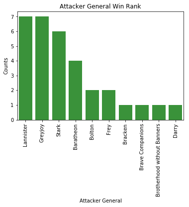

```python
# Q0: 哪个将领赢得了更多的胜利（作为攻方）？
# A0: Lannister和Greyjoy都赢了7场

# attacker general wins rank
battle_attwins = battle[battle['attacker_outcome'] == 'win']
cat_order = battle_attwins['attacker_1'].value_counts().index
sb.countplot(data = battle_attwins, x = 'attacker_1', color=sb.color_palette()[2], order=cat_order)
plt.xticks(rotation = 90)
plt.ylabel('Counts')
plt.xlabel('Attacker General')
plt.title('Attacker General Win Rank')
```

```
Text(0.5,1,'Attacker King Battle Type Preference')
```

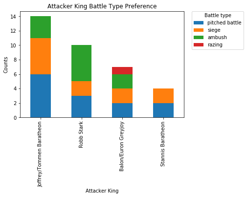

```python
# Q1:攻防国王的战争类型偏好
# A1:可以看出Joffery/Tommen Baratheon更喜欢发动piched battle和siege; Robb Stark偏爱ambush;
# Balon/Euron Greyjoy则是各类型的战役都发动过；Stannis Baratheon为数不多的进攻中只有pitched battle和siege两种

battle_plot = battle.groupby(['attacker_king', 'battle_type']).size().sort_values(ascending=False).reset_index().pivot(columns='battle_type', index='attacker_king', values=0)
#reindex the kings according to the total attacks
cat_order = battle['attacker_king'].value_counts().index
battle_plot = battle_plot.reindex(index = cat_order)
#reindex the battle types according to sum of certain type
battle_plot = battle_plot.reindex_axis(battle_plot.sum().sort_values(ascending = False).index, axis=1)
# plot stacked bar chart
battle_plot.plot(x=battle_plot.index, kind='bar', stacked=True)
plt.legend(bbox_to_anchor=(1.05, 1), loc=2, borderaxespad=0., title = 'Battle type')
plt.ylabel('Counts')
plt.xlabel('Attacker King')
plt.title('Attacker King Battle Type Preference')
```

```
In 15 battles, only 3 battles winned by the side with more attackers
```

```
Text(0.5,1,'Attack Outcome in Relation to Attacker Size/Defender Size')
```

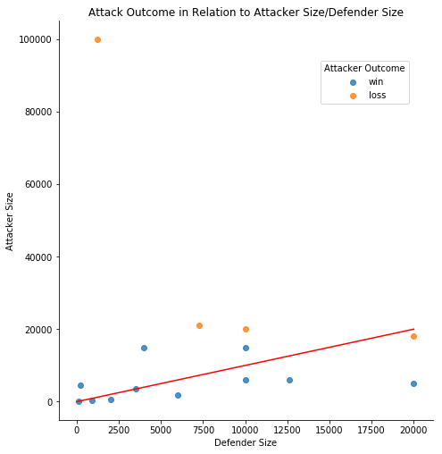

```python
# Q2: 胜负与兵力多少的关系
# A2: 红线上方代表人数占优，可以看出在15场有相关统计的战争中，只有3场人数占优一方获得胜利。所以胜利并不因为人数众多。
# dropping rows with null value in 'attacker_size', 'defender_size','attacker_outcome'

battle_2 = battle.dropna(subset = ['attacker_size', 'defender_size','attacker_outcome'])
win_with_more_attacker = battle_2[(battle_2['attacker_size'] > battle_2['defender_size']) & (battle_2['attacker_outcome'] == 'win')]
print("In {} battles, only {} battles winned by the side with more attackers".format(battle_2.shape[0], win_with_more_attacker.shape[0]))

sb.lmplot(data = battle_2, x = 'defender_size', y = 'attacker_size', hue='attacker_outcome', fit_reg=False, size=7, legend=False)
plt.plot(np.linspace(0,20000,1000), np.linspace(0,20000,1000), 'r-')
battle_2.head(15)
plt.legend(bbox_to_anchor=(0.7, 0.9), loc=2, borderaxespad=0., title = 'Attacker Outcome')
plt.ylabel('Attacker Size')
plt.xlabel('Defender Size')
plt.title('Attack Outcome in Relation to Attacker Size/Defender Size')
```

```
Text(0.5,1,'Win Rate in Relation to Summer/Not Summer')
```

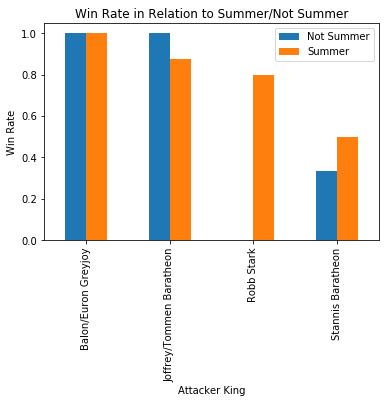

```python
# Q3: 各个国王战争结果与夏季与否的关系
# A3: 可以看出Joffrey/Tommen Baratheon夏天胜率略低于非夏天; Stannis Baratheon则是夏天胜率相对较高；
# Balon/Euron Greyjoy无论夏天与否，作为进攻方都是全胜；而Rob Stark只有夏天时发动过进攻，没有冬天的数据

# summer:
battle_summer = battle[battle['summer'] == 'Yes']
battle_summer_win = battle_summer[battle_summer['attacker_outcome'] == 'win']
battle_summer_win = battle_summer_win.dropna(subset=['attacker_king'])
summer_num = battle_summer.groupby(['attacker_king']).size()
summer_win_num = battle_summer_win.groupby(['attacker_king']).size()
# not summer:
battle_notsummer = battle[battle['summer'] == 'No']
battle_notsummer_win = battle_notsummer[battle_notsummer['attacker_outcome'] == 'win']
battle_notsummer_win = battle_notsummer_win.dropna(subset=['attacker_king'])
notsummer_num = battle_notsummer.groupby(['attacker_king']).size()
notsummer_win_num = battle_notsummer_win.groupby(['attacker_king']).size()
# build new frame to present win rate in relation with summer
summer_win_rate = summer_win_num / summer_num
notsummer_win_rate = notsummer_win_num / notsummer_num
battle_win_rate = pd.DataFrame({'Summer': summer_win_rate, 'Not Summer': notsummer_win_rate})
battle_win_rate.plot.bar()
plt.xlabel('Attacker King')
plt.ylabel('Win Rate')
plt.title('Win Rate in Relation to Summer/Not Summer')
```

```python
# change attacker_outcome and summer into int
def outcome_transfer(outcome):
    if outcome == 'loss':
        return 0
    else:
        return 1

def summer_transfer(summer):
    if summer == 'Yes':
        return 1
    else:
        return 0

battle.loc[:, ['attacker_outcome']] = battle.loc[:, ['attacker_outcome']].applymap(outcome_transfer)
battle.loc[:, ['summer']] = battle.loc[:, ['summer']].applymap(summer_transfer)
```

```python
# Q4: correlation between outcome and summer
# A4: -0.097, the correlation is very weak
corr_outcome_summer = battle['attacker_outcome'].corr(battle['summer'])
print("Correlation between outcome and summer is : {:.3f}".format(corr_outcome_summer))
```

```
Correlation between outcome and summer is : -0.097
```

```python
# Q5: correlation between outcome and more attacker
# A5: -0.431, correlation is negative and relatively strong
more_attacker = battle_2['attacker_size'] > battle_2['defender_size']
more_attacker = more_attacker.to_frame(name='more_attacker')
battle_2_extend = pd.concat([battle_2, more_attacker],join='outer',axis=1)

def more_attacker_transfer(more_attacker):
    if more_attacker == True:
        return 1
    else:
        return 0

battle_2_extend.head()
battle_2_extend.loc[:, ['more_attacker']] = battle_2_extend.loc[:, ['more_attacker']].applymap(more_attacker_transfer)
battle_2_extend.loc[:, ['attacker_outcome']] = battle_2_extend.loc[:, ['attacker_outcome']].applymap(outcome_transfer)

corr_outcome_moreattacker = battle_2_extend['attacker_outcome'].corr(battle_2_extend['more_attacker'])
print("Correlation between outcome and more attacker is : {:.3f}".format(corr_outcome_moreattacker))
```

```
Correlation between outcome and more attacker is : -0.431
```

在数据的探索性分析中，请确保你对数据分析中的关键步骤和推理过程进行了记录。你可以自己插入code cell和markdown cell来组织你的报告。

## 得出结论

**问题**：上面的分析能够回答你提出的问题？通过这些分析你能够得出哪些结论？

**答案**：  
Q0: 哪个将领赢得了更多的胜利（作为攻方）？ A0: Lannister和Greyjoy都赢了7场。

Q1:攻防国王的战争类型偏好? A1:可以看出Joffery/Tommen Baratheon更喜欢发动piched battle和siege; Robb Stark偏爱ambush; Balon/Euron Greyjoy则是各类型的战役都发动过；Stannis Baratheon为数不多的进攻中只有pitched battle和siege两种。

Q2: 胜负与兵力多少的关系？ A2: 红线上方代表人数占优，可以看出在15场有相关统计的战争中，只有3场人数占优一方获得胜利。所以胜利并不因为人数众多。

Q3: 各个国王战争结果与夏季与否的关系？ A3: 可以看出Joffrey/Tommen Baratheon夏天胜率略低于非夏天; Stannis Baratheon则是夏天胜率相对较高； Balon/Euron Greyjoy无论夏天与否，作为进攻方都是全胜；而Rob Stark只有夏天时发动过进攻，没有冬天的数据。

Q4: 胜利与夏季的相关性？ A4: -0.097, 相关性很低。

Q5: 胜利与更多进攻方的相关性？ A5: -0.431, 相关性较高，负相关。

## 反思

**问题**：在你的分析和总结过程中是否存在逻辑严谨。是否有改进的空间? 你可以从下面的一些角度进行思考：

1. 数据集是否完整，包含所有想要分析的数据？
2. 在对数据进行处理的时候，你的操作（例如删除/填充缺失值）是否可能影响结论？
3. 是否还有其他变量（本数据中没有）能够对你的分析有帮助？
4. 在得出结论时，你是否混淆了相关性和因果性？

**答案**：

1. 数据集的行数较少，得出的结论偶然性比较大。
2. 我在数据清洗是都是采用删除缺失项，不会影响结论。
3. 如下数据都可能会提供帮助：发动战争的理由，战争的策略，战争持续的时间等。
4. 此处的分析都仅仅是相关性，不是因果性。

恭喜你完成了此项目！这只是数据分析过程的一个样本：从生成问题、整理数据、探索数据到得出结论。在数据分析(进阶)纳米学位中，你将会学到更多高级的数据分析方法和技术，如果你感兴趣的话，我们鼓励你继续学习后续的课程，掌握更多的数据分析的高级技能！

> 若想与他人分享我们的分析结果，除了向他们提供 jupyter Notebook (.ipynb) 文件的副本外，我们还可以将 Notebook 输出导出为一种甚至那些未安装 Python 的人都能打开的形式。从左上方的“文件”菜单，前往“下载为”子菜单。然后你可以选择一个可以更普遍查看的格式，例如 HTML (.html) 。你可能需要额外软件包或软件来执行这些导出。